# How much is a muscle-up worth?

Open 13.3

Stefan

2022-02-06

Here’s a quick analysis of the 13.3 Open Workout. The workout is an AMRAP in 12 minutes of

- 150 Wall balls (WB)
- 90 Double-unders (DU)
- 30 Muscle-ups (MU)

I will look at RX scores only.

The WOD comes with two movements that require technical skill: double-unders and muscle-ups so we’d expect these to be natural points where people stop. For example if you cannot perform a muscle-up, but can do wall balls and double-unders sufficiently well, you will hit 240 reps (150 wall balls, 90 double unders).

This workout actually came with a tie-breaker: if two athletes hit 240 repetitions each, the one how did so earlier scores more points. But scoring that first muscle-up at rep 241 will put you above all others with 240 reps! How many points will this give you on the leaderboard? Well let’s have a look at the scored repetitions from this workout:

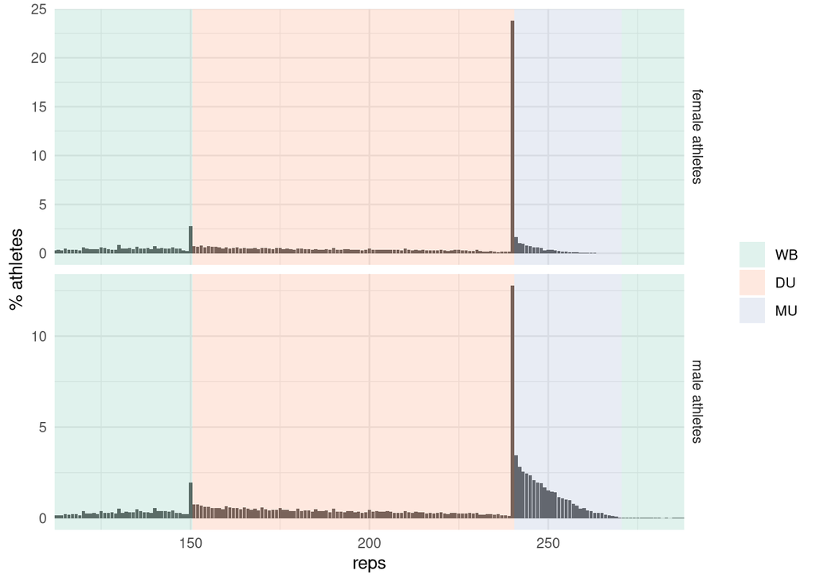

That’s a lot of athletes hitting the 240 mark, both for female and male athletes (though the effect is more pronounced for females, as muscle-ups typically also require a lot of upper-body strength).

Athletes scoring 150 WB + 90 DU

| gender | total | fraction [%] |
| --- | --- | --- |
| female | 7253 | 23.81 |
| male | 6093 | 12.78 |

This is how much having at least one muscle-up (and making it through the 150 WB and 90 DU) were worth in 13.3: 7253 places for females and 6093 for males (there were a lot more male athletes in this open which explains why the fractions are so far apart).

Stay tuned for more analyses leading up to the 2022 open!